# PW7

Pierrick PINPIN

2022-11-22

# Question 1

```r
library(FactoMineR)
library(factoextra)
```

# Question 2

```r
data <- data("decathlon2")
head(decathlon2)
```

```
##           X100m Long.jump Shot.put High.jump X400m X110m.hurdle Discus
## SEBRLE    11.04      7.58    14.83      2.07 49.81        14.69  43.75
## CLAY      10.76      7.40    14.26      1.86 49.37        14.05  50.72
## BERNARD   11.02      7.23    14.25      1.92 48.93        14.99  40.87
## YURKOV    11.34      7.09    15.19      2.10 50.42        15.31  46.26
## ZSIVOCZKY 11.13      7.30    13.48      2.01 48.62        14.17  45.67
## McMULLEN  10.83      7.31    13.76      2.13 49.91        14.38  44.41
##           Pole.vault Javeline X1500m Rank Points Competition
## SEBRLE          5.02    63.19  291.7    1   8217    Decastar
## CLAY            4.92    60.15  301.5    2   8122    Decastar
## BERNARD         5.32    62.77  280.1    4   8067    Decastar
## YURKOV          4.72    63.44  276.4    5   8036    Decastar
## ZSIVOCZKY       4.42    55.37  268.0    7   8004    Decastar
## McMULLEN        4.42    56.37  285.1    8   7995    Decastar
```

#Question 3

```r
str(decathlon2)
```

```
## 'data.frame':    27 obs. of  13 variables:
##  $ X100m       : num  11 10.8 11 11.3 11.1 ...
##  $ Long.jump   : num  7.58 7.4 7.23 7.09 7.3 7.31 6.81 7.56 6.97 7.27 ...
##  $ Shot.put    : num  14.8 14.3 14.2 15.2 13.5 ...
##  $ High.jump   : num  2.07 1.86 1.92 2.1 2.01 2.13 1.95 1.86 1.95 1.98 ...
##  $ X400m       : num  49.8 49.4 48.9 50.4 48.6 ...
##  $ X110m.hurdle: num  14.7 14.1 15 15.3 14.2 ...
##  $ Discus      : num  43.8 50.7 40.9 46.3 45.7 ...
##  $ Pole.vault  : num  5.02 4.92 5.32 4.72 4.42 4.42 4.92 4.82 4.72 4.62 ...
##  $ Javeline    : num  63.2 60.1 62.8 63.4 55.4 ...
##  $ X1500m      : num  292 302 280 276 268 ...
##  $ Rank        : int  1 2 4 5 7 8 9 10 11 12 ...
##  $ Points      : int  8217 8122 8067 8036 8004 7995 7802 7733 7708 7651 ...
##  $ Competition : Factor w/ 2 levels "Decastar","OlympicG": 1 1 1 1 1 1 1 1 1 1 ...
```

> We can see 27 individuals and 13 variables: - 23 Active individuals - 4 Supplementary individuals - 10 Active variables - 3 Supplementary variables

> Let’s extract the active individuals, variables and scale variables.

# Question 4

```r
active.data <- decathlon2[1:23,1:10]

active.data <- scale(active.data, center = TRUE, scale = TRUE)
head(active.data)
```

```
##                 X100m  Long.jump   Shot.put  High.jump       X400m X110m.hurdle
## SEBRLE     0.13427173  0.7352966  0.2486090  0.6475727  0.37430757    0.3225903
## CLAY      -0.79552392  0.1609328 -0.4261868 -1.5244940 -0.06260046   -1.0001196
## BERNARD    0.06785776 -0.3815218 -0.4380253 -0.9039035 -0.49950849    0.9426105
## YURKOV     1.13048136 -0.8282492  0.6747957  0.9578679  0.98002098    1.6039655
## ZSIVOCZKY  0.43313462 -0.1581581 -1.3495915  0.0269822 -0.80733006   -0.7521115
## McMULLEN  -0.56307501 -0.1262490 -1.0181129  1.2681632  0.47360485   -0.3180974
##               Discus Pole.vault   Javeline     X1500m
## SEBRLE    -0.4240585  0.8955030  0.8265919  1.3806309
## CLAY       1.6715277  0.4947915  0.2099771  2.3595061
## BERNARD   -1.2899535  2.0976374  0.7414017  0.2219623
## YURKOV     0.3305931 -0.3066314  0.8773003 -0.1476130
## ZSIVOCZKY  0.1532048 -1.5087658 -0.7595685 -0.9866488
## McMULLEN  -0.2256242 -1.5087658 -0.5567347  0.7213884
```

# Question 5

```r
active.pca <- PCA(active.data)
```

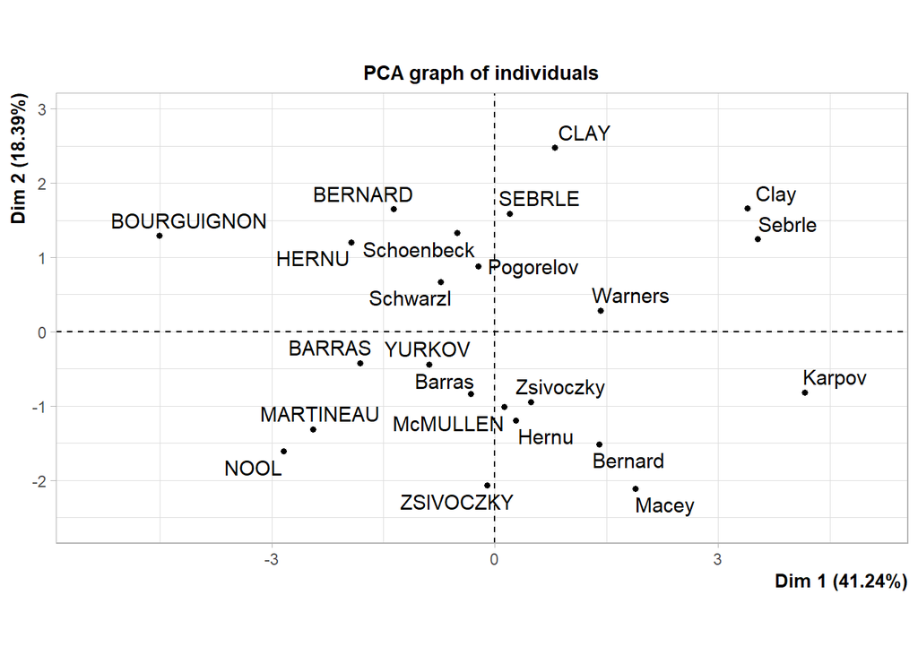

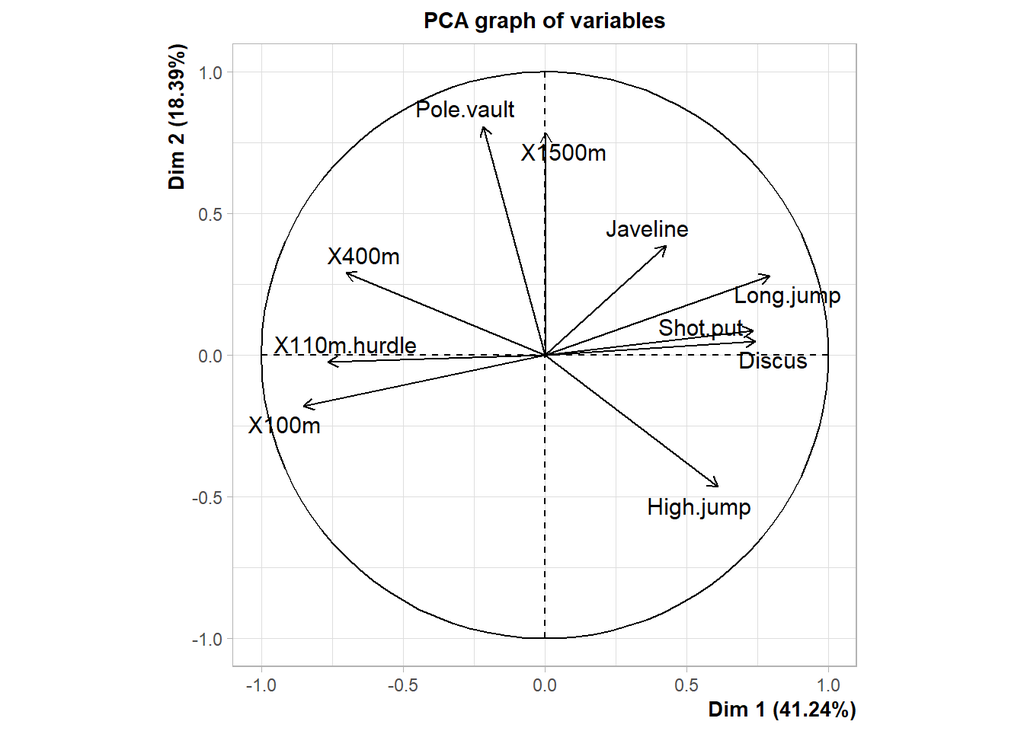

# Question 6

```r
summary(active.pca)
```

```
##
## Call:
## PCA(X = active.data)
##
##
## Eigenvalues
##                        Dim.1   Dim.2   Dim.3   Dim.4   Dim.5   Dim.6   Dim.7
## Variance               4.124   1.839   1.239   0.819   0.702   0.423   0.303
## % of var.             41.242  18.385  12.391   8.194   7.016   4.229   3.026
## Cumulative % of var.  41.242  59.627  72.019  80.213  87.229  91.458  94.483
##                        Dim.8   Dim.9  Dim.10
## Variance               0.274   0.155   0.122
## % of var.              2.745   1.552   1.220
## Cumulative % of var.  97.228  98.780 100.000
##
## Individuals (the 10 first)
##                  Dist    Dim.1    ctr   cos2    Dim.2    ctr   cos2    Dim.3
## SEBRLE       |  2.253 |  0.196  0.040  0.008 |  1.589  5.971  0.497 |  0.642
## CLAY         |  3.661 |  0.808  0.688  0.049 |  2.475 14.484  0.457 | -1.387
## BERNARD      |  3.061 | -1.359  1.947  0.197 |  1.648  6.423  0.290 |  0.201
## YURKOV       |  2.867 | -0.889  0.833  0.096 | -0.443  0.463  0.024 |  2.530
## ZSIVOCZKY    |  2.725 | -0.108  0.012  0.002 | -2.069 10.122  0.576 | -1.334
## McMULLEN     |  2.599 |  0.121  0.015  0.002 | -1.014  2.431  0.152 | -0.863
## MARTINEAU    |  3.848 | -2.446  6.308  0.404 | -1.314  4.082  0.117 |  0.918
## HERNU        |  3.060 | -1.934  3.941  0.399 |  1.205  3.434  0.155 |  0.160
## BARRAS       |  2.311 | -1.814  3.470  0.616 | -0.422  0.421  0.033 | -0.673
## NOOL         |  4.057 | -2.839  8.499  0.490 | -1.608  6.115  0.157 | -0.621
##                 ctr   cos2
## SEBRLE        1.448  0.081 |
## CLAY          6.754  0.144 |
## BERNARD       0.141  0.004 |
## YURKOV       22.452  0.778 |
## ZSIVOCZKY     6.246  0.240 |
## McMULLEN      2.610  0.110 |
## MARTINEAU     2.959  0.057 |
## HERNU         0.090  0.003 |
## BARRAS        1.589  0.085 |
## NOOL          1.353  0.023 |
##
## Variables
##                 Dim.1    ctr   cos2    Dim.2    ctr   cos2    Dim.3    ctr
## X100m        | -0.851 17.544  0.724 | -0.179  1.751  0.032 |  0.302  7.339
## Long.jump    |  0.794 15.293  0.631 |  0.281  4.290  0.079 | -0.191  2.930
## Shot.put     |  0.734 13.060  0.539 |  0.085  0.397  0.007 |  0.518 21.620
## High.jump    |  0.610  9.025  0.372 | -0.465 11.772  0.216 |  0.330  8.793
## X400m        | -0.702 11.936  0.492 |  0.290  4.580  0.084 |  0.284  6.488
## X110m.hurdle | -0.764 14.158  0.584 | -0.025  0.033  0.001 |  0.449 16.261
## Discus       |  0.743 13.393  0.552 |  0.050  0.134  0.002 |  0.177  2.515
## Pole.vault   | -0.217  1.145  0.047 |  0.807 35.462  0.652 |  0.094  0.714
## Javeline     |  0.428  4.446  0.183 |  0.386  8.109  0.149 |  0.604 29.453
## X1500m       |  0.004  0.000  0.000 |  0.784 33.473  0.615 | -0.219  3.887
##                cos2
## X100m         0.091 |
## Long.jump     0.036 |
## Shot.put      0.268 |
## High.jump     0.109 |
## X400m         0.080 |
## X110m.hurdle  0.201 |
## Discus        0.031 |
## Pole.vault    0.009 |
## Javeline      0.365 |
## X1500m        0.048 |
```

> Extract the eigenvalues/variances of principal components

```r
active.pca$eig #or
```

```
##         eigenvalue percentage of variance cumulative percentage of variance
## comp 1   4.1242133              41.242133                          41.24213
## comp 2   1.8385309              18.385309                          59.62744
## comp 3   1.2391403              12.391403                          72.01885
## comp 4   0.8194402               8.194402                          80.21325
## comp 5   0.7015528               7.015528                          87.22878
## comp 6   0.4228828               4.228828                          91.45760
## comp 7   0.3025817               3.025817                          94.48342
## comp 8   0.2744700               2.744700                          97.22812
## comp 9   0.1552169               1.552169                          98.78029
## comp 10  0.1219710               1.219710                         100.00000
```

```r
#get_eigenvalue(active.pca)
```

> Visualize the eigenvalues

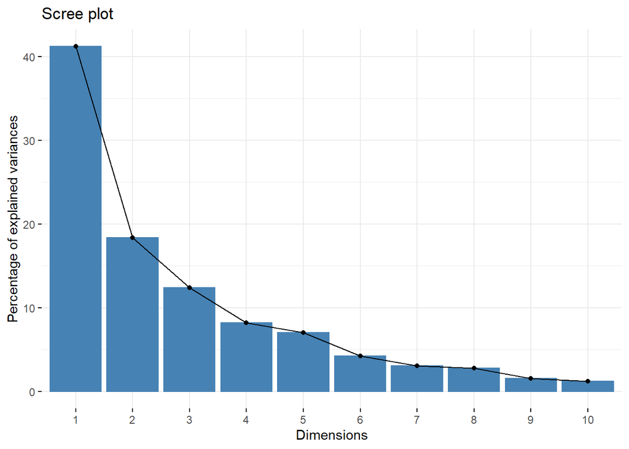

```r
fviz_eig(active.pca)
```

>Extract the results for individuals and visualize it:

```r
vind <- get_pca_ind(active.pca)
head(vind$coord)
```

```
##                Dim.1      Dim.2      Dim.3       Dim.4       Dim.5
## SEBRLE     0.1955047  1.5890567  0.6424912  0.08389652  1.16829387
## CLAY       0.8078795  2.4748137 -1.3873827  1.29838232 -0.82498206
## BERNARD   -1.3591340  1.6480950  0.2005584 -1.96409420  0.08419345
## YURKOV    -0.8889532 -0.4426067  2.5295843  0.71290837  0.40782264
## ZSIVOCZKY -0.1081216 -2.0688377 -1.3342591 -0.10152796 -0.20145217
## McMULLEN   0.1212195 -1.0139102 -0.8625170  1.34164291  1.62151286
```

```r
head(vind$cos2)
```

```
##                 Dim.1      Dim.2       Dim.3       Dim.4        Dim.5
## SEBRLE    0.007530179 0.49747323 0.081325232 0.001386688 0.2689026575
## CLAY      0.048701249 0.45701660 0.143628117 0.125791741 0.0507850580
## BERNARD   0.197199804 0.28996555 0.004294015 0.411819183 0.0007567259
## YURKOV    0.096109800 0.02382571 0.778230322 0.061812637 0.0202279796
## ZSIVOCZKY 0.001574385 0.57641944 0.239754152 0.001388216 0.0054654972
## McMULLEN  0.002175437 0.15219499 0.110137872 0.266486530 0.3892621478
```

```r
head(vind$contrib)
```

```
##                Dim.1      Dim.2      Dim.3       Dim.4       Dim.5
## SEBRLE    0.04029447  5.9714533  1.4483919  0.03734589  8.45894063
## CLAY      0.68805664 14.4839248  6.7537381  8.94458283  4.21794385
## BERNARD   1.94740183  6.4234107  0.1411345 20.46819433  0.04393073
## YURKOV    0.83308415  0.4632733 22.4517396  2.69663605  1.03075263
## ZSIVOCZKY 0.01232413 10.1217143  6.2464325  0.05469230  0.25151025
## McMULLEN  0.01549089  2.4310854  2.6102794  9.55055888 16.29493304
```

```r
vind$dist
```

```
##      SEBRLE        CLAY     BERNARD      YURKOV   ZSIVOCZKY    McMULLEN
##    2.252966    3.660804    3.060617    2.867445    2.724941    2.598958
##   MARTINEAU       HERNU      BARRAS        NOOL BOURGUIGNON      Sebrle
##    3.848396    3.059956    2.311227    4.056839    4.867273    4.294174
##        Clay      Karpov       Macey     Warners   Zsivoczky       Hernu
##    4.089129    4.701314    3.135084    2.805527    2.271541    1.793136
##     Bernard    Schwarzl   Pogorelov  Schoenbeck      Barras
##    2.598924    2.125717    2.481059    1.955559    2.344874
```

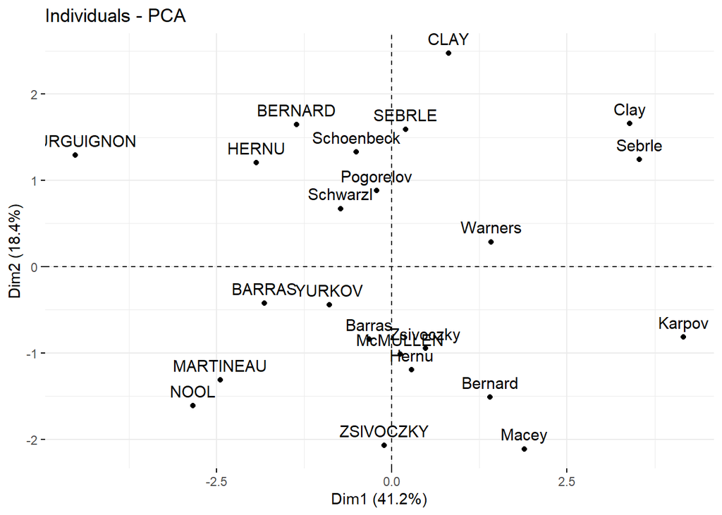

```r
fviz_pca_ind(active.pca)
```

> Extract the results for variables and visualize it:

```r
vvar <- get_pca_var(active.pca)
head(vvar$coord)
```

```
##                   Dim.1       Dim.2      Dim.3       Dim.4      Dim.5
## X100m        -0.8506257 -0.17939806  0.3015564  0.03357320 -0.1944440
## Long.jump     0.7941806  0.28085695 -0.1905465 -0.11538956  0.2331567
## Shot.put      0.7339127  0.08540412  0.5175978  0.12846837 -0.2488129
## High.jump     0.6100840 -0.46521415  0.3300852  0.14455012  0.4027002
## X400m        -0.7016034  0.29017826  0.2835329  0.43082552  0.1039085
## X110m.hurdle -0.7641252 -0.02474081  0.4488873 -0.01689589  0.2242200
```

```r
head(vvar$cor)
```

```
##                   Dim.1       Dim.2      Dim.3       Dim.4      Dim.5
## X100m        -0.8506257 -0.17939806  0.3015564  0.03357320 -0.1944440
## Long.jump     0.7941806  0.28085695 -0.1905465 -0.11538956  0.2331567
## Shot.put      0.7339127  0.08540412  0.5175978  0.12846837 -0.2488129
## High.jump     0.6100840 -0.46521415  0.3300852  0.14455012  0.4027002
## X400m        -0.7016034  0.29017826  0.2835329  0.43082552  0.1039085
## X110m.hurdle -0.7641252 -0.02474081  0.4488873 -0.01689589  0.2242200
```

```r
head(vvar$cos2)
```

```
##                  Dim.1        Dim.2      Dim.3        Dim.4      Dim.5
## X100m        0.7235641 0.0321836641 0.09093628 0.0011271597 0.03780845
## Long.jump    0.6307229 0.0788806285 0.03630798 0.0133147506 0.05436203
## Shot.put     0.5386279 0.0072938636 0.26790749 0.0165041211 0.06190783
## High.jump    0.3722025 0.2164242070 0.10895622 0.0208947375 0.16216747
## X400m        0.4922473 0.0842034209 0.08039091 0.1856106269 0.01079698
## X110m.hurdle 0.5838873 0.0006121077 0.20149984 0.0002854712 0.05027463
```

```r
head(vvar$contrib)
```

```
##                  Dim.1      Dim.2     Dim.3       Dim.4     Dim.5
## X100m        17.544293  1.7505098  7.338659  0.13755240  5.389252
## Long.jump    15.293168  4.2904162  2.930094  1.62485936  7.748815
## Shot.put     13.060137  0.3967224 21.620432  2.01407269  8.824401
## High.jump     9.024811 11.7715838  8.792888  2.54987951 23.115504
## X400m        11.935544  4.5799296  6.487636 22.65090599  1.539012
## X110m.hurdle 14.157544  0.0332933 16.261261  0.03483735  7.166193
```

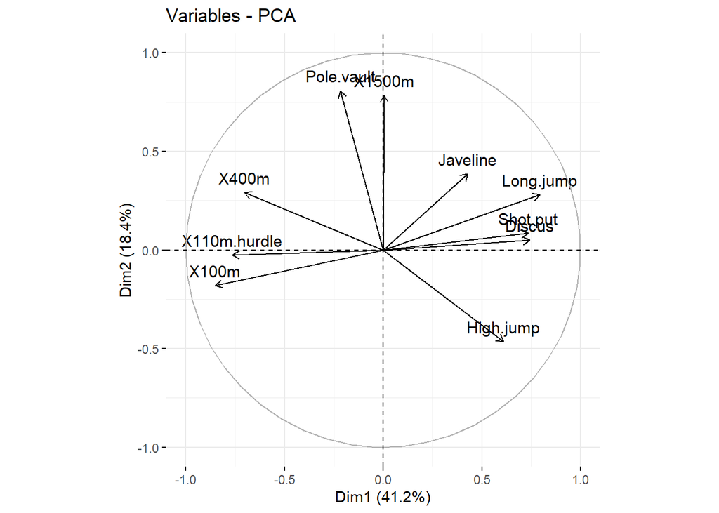

```r
fviz_pca_var(active.pca)
```

>Let’s make a biplot of individuals and variables. Superimposes the graphs of individuals and variables.

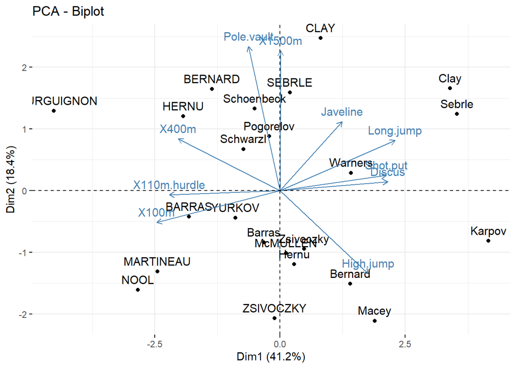

```r
fviz_pca_biplot(active.pca)
```

# Question 7

> Let’s determine the number of principal components to be analysed. There are 3 ways to do it:

```r
eigv <- active.pca$eig
eigv
```

```
##         eigenvalue percentage of variance cumulative percentage of variance
## comp 1   4.1242133              41.242133                          41.24213
## comp 2   1.8385309              18.385309                          59.62744
## comp 3   1.2391403              12.391403                          72.01885
## comp 4   0.8194402               8.194402                          80.21325
## comp 5   0.7015528               7.015528                          87.22878
## comp 6   0.4228828               4.228828                          91.45760
## comp 7   0.3025817               3.025817                          94.48342
## comp 8   0.2744700               2.744700                          97.22812
## comp 9   0.1552169               1.552169                          98.78029
## comp 10  0.1219710               1.219710                         100.00000
```

> Kaiser criteria: We count the number of components with eigenvalues greater than 1

```r
eigv2 <- ifelse(eigv > 1, TRUE, FALSE)
eigv2
```

```
##         eigenvalue percentage of variance cumulative percentage of variance
## comp 1        TRUE                   TRUE                              TRUE
## comp 2        TRUE                   TRUE                              TRUE
## comp 3        TRUE                   TRUE                              TRUE
## comp 4       FALSE                   TRUE                              TRUE
## comp 5       FALSE                   TRUE                              TRUE
## comp 6       FALSE                   TRUE                              TRUE
## comp 7       FALSE                   TRUE                              TRUE
## comp 8       FALSE                   TRUE                              TRUE
## comp 9       FALSE                   TRUE                              TRUE
## comp 10      FALSE                   TRUE                              TRUE
```

```r
sum(eigv2, na.rm = TRUE)-2*10
```

```
## [1] 3
```

```r
#Remove the number of TRUE from the other columns (percentage of variance cumulative and percentage of variance)
```

> We can see that only 3 components have their eigenvalues which are higher than 1. So, we can conclude that these 3 components are the principal components.

> Limit the number of component: We look at the cumulative variance and choose the number of components with a cumulative variance above a given threshold. Here, let’s choose 70%.

```r
eigv3 <- ifelse(eigv > 70, TRUE, FALSE)
eigv3
```

```
##         eigenvalue percentage of variance cumulative percentage of variance
## comp 1       FALSE                  FALSE                             FALSE
## comp 2       FALSE                  FALSE                             FALSE
## comp 3       FALSE                  FALSE                              TRUE
## comp 4       FALSE                  FALSE                              TRUE
## comp 5       FALSE                  FALSE                              TRUE
## comp 6       FALSE                  FALSE                              TRUE
## comp 7       FALSE                  FALSE                              TRUE
## comp 8       FALSE                  FALSE                              TRUE
## comp 9       FALSE                  FALSE                              TRUE
## comp 10      FALSE                  FALSE                              TRUE
```

> We can see that from component 3, the condition is satisfied. Thus, the principal components are the first 3.

# Question 8

> Scree Plot

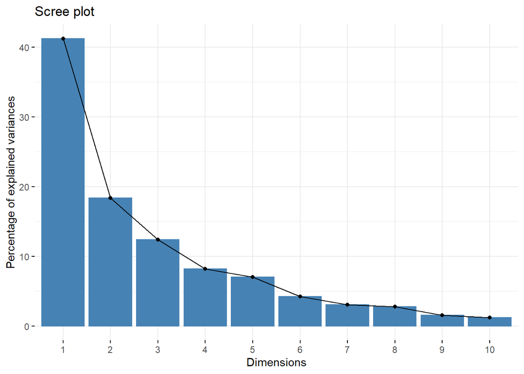

```r
fviz_eig(active.pca)
```

>We can see on the Scree plot that from the 3rd or 5th dimension, the percentage of explanation of the variance of the other dimensions are comparable. It is very difficult to distinguish the optimal number of dimensions.

#Question 9

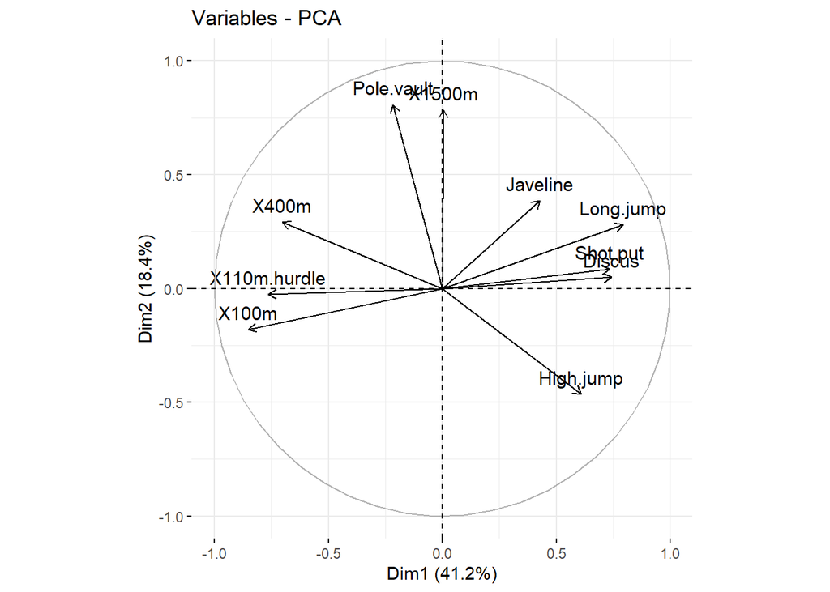

```r
fviz_pca_var(active.pca)
```

# Question 10

```r
vvar$cos2
```

```
##                     Dim.1        Dim.2       Dim.3        Dim.4      Dim.5
## X100m        7.235641e-01 0.0321836641 0.090936280 0.0011271597 0.03780845
## Long.jump    6.307229e-01 0.0788806285 0.036307981 0.0133147506 0.05436203
## Shot.put     5.386279e-01 0.0072938636 0.267907488 0.0165041211 0.06190783
## High.jump    3.722025e-01 0.2164242070 0.108956221 0.0208947375 0.16216747
## X400m        4.922473e-01 0.0842034209 0.080390914 0.1856106269 0.01079698
## X110m.hurdle 5.838873e-01 0.0006121077 0.201499837 0.0002854712 0.05027463
## Discus       5.523596e-01 0.0024662013 0.031161138 0.1560322304 0.16665918
## Pole.vault   4.720540e-02 0.6519772763 0.008846856 0.1149106765 0.04914437
## Javeline     1.833781e-01 0.1490803723 0.364966189 0.1100478063 0.03912992
## X1500m       1.830545e-05 0.6154091638 0.048167378 0.2007126089 0.06930197
```

# Question 11

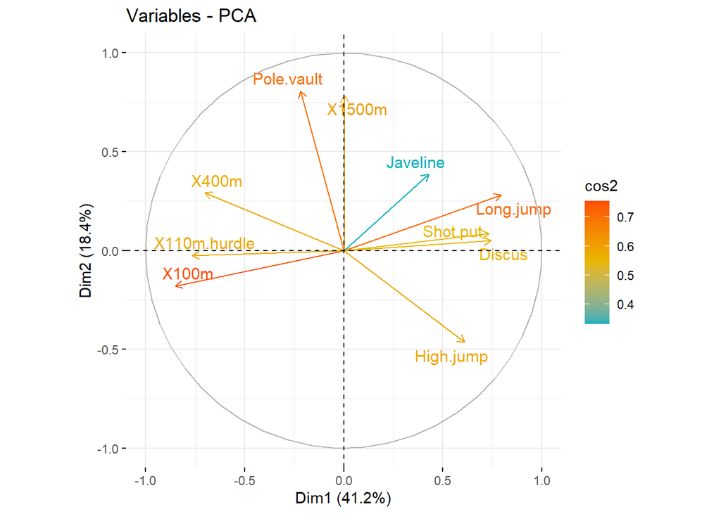

```r
fviz_pca_var(active.pca, col.var = "cos2",
             gradient.cols = c("#00AFBB", "#E7B800", "#FC4E07"),
             repel = TRUE
             )
```

>We can see that the variables with the highest cos² and therefore the best representation qualities are: - X100m (Dim1= 7.235641e-01, Dim2= 0.0321836641) - Long.jump (Dim1= 6.307229e-01, Dim2= 0.0788806285) - Pole.vault (Dim1= 4.720540e-02, Dim2= 0.6519772763)

# Question 12

```r
dimdesc(active.pca)
```

```
## $Dim.1
##
## Link between the variable and the continuous variables (R-square)
## =================================================================================
##              correlation      p.value
## Long.jump      0.7941806 6.059893e-06
## Discus         0.7432090 4.842563e-05
## Shot.put       0.7339127 6.723102e-05
## High.jump      0.6100840 1.993677e-03
## Javeline       0.4282266 4.149192e-02
## X400m         -0.7016034 1.910387e-04
## X110m.hurdle  -0.7641252 2.195812e-05
## X100m         -0.8506257 2.727129e-07
##
## $Dim.2
##
## Link between the variable and the continuous variables (R-square)
## =================================================================================
##            correlation      p.value
## Pole.vault   0.8074511 3.205016e-06
## X1500m       0.7844802 9.384747e-06
## High.jump   -0.4652142 2.529390e-02
##
## $Dim.3
##
## Link between the variable and the continuous variables (R-square)
## =================================================================================
##              correlation     p.value
## Javeline       0.6041243 0.002266783
## Shot.put       0.5175978 0.011419547
## X110m.hurdle   0.4488873 0.031667860
```

> The most significantly associated variables with first principal components are:

```r
d1 <- dimdesc(active.pca)
d1
```

```
## $Dim.1
##
## Link between the variable and the continuous variables (R-square)
## =================================================================================
##              correlation      p.value
## Long.jump      0.7941806 6.059893e-06
## Discus         0.7432090 4.842563e-05
## Shot.put       0.7339127 6.723102e-05
## High.jump      0.6100840 1.993677e-03
## Javeline       0.4282266 4.149192e-02
## X400m         -0.7016034 1.910387e-04
## X110m.hurdle  -0.7641252 2.195812e-05
## X100m         -0.8506257 2.727129e-07
##
## $Dim.2
##
## Link between the variable and the continuous variables (R-square)
## =================================================================================
##            correlation      p.value
## Pole.vault   0.8074511 3.205016e-06
## X1500m       0.7844802 9.384747e-06
## High.jump   -0.4652142 2.529390e-02
##
## $Dim.3
##
## Link between the variable and the continuous variables (R-square)
## =================================================================================
##              correlation     p.value
## Javeline       0.6041243 0.002266783
## Shot.put       0.5175978 0.011419547
## X110m.hurdle   0.4488873 0.031667860
```

# Question 13

```r
vind <- get_pca_ind(active.pca)
head(vvar$coord)
```

```
##                   Dim.1       Dim.2      Dim.3       Dim.4      Dim.5
## X100m        -0.8506257 -0.17939806  0.3015564  0.03357320 -0.1944440
## Long.jump     0.7941806  0.28085695 -0.1905465 -0.11538956  0.2331567
## Shot.put      0.7339127  0.08540412  0.5175978  0.12846837 -0.2488129
## High.jump     0.6100840 -0.46521415  0.3300852  0.14455012  0.4027002
## X400m        -0.7016034  0.29017826  0.2835329  0.43082552  0.1039085
## X110m.hurdle -0.7641252 -0.02474081  0.4488873 -0.01689589  0.2242200
```

```r
head(vvar$cor)
```

```
##                   Dim.1       Dim.2      Dim.3       Dim.4      Dim.5
## X100m        -0.8506257 -0.17939806  0.3015564  0.03357320 -0.1944440
## Long.jump     0.7941806  0.28085695 -0.1905465 -0.11538956  0.2331567
## Shot.put      0.7339127  0.08540412  0.5175978  0.12846837 -0.2488129
## High.jump     0.6100840 -0.46521415  0.3300852  0.14455012  0.4027002
## X400m        -0.7016034  0.29017826  0.2835329  0.43082552  0.1039085
## X110m.hurdle -0.7641252 -0.02474081  0.4488873 -0.01689589  0.2242200
```

```r
head(vvar$cos2)
```

```
##                  Dim.1        Dim.2      Dim.3        Dim.4      Dim.5
## X100m        0.7235641 0.0321836641 0.09093628 0.0011271597 0.03780845
## Long.jump    0.6307229 0.0788806285 0.03630798 0.0133147506 0.05436203
## Shot.put     0.5386279 0.0072938636 0.26790749 0.0165041211 0.06190783
## High.jump    0.3722025 0.2164242070 0.10895622 0.0208947375 0.16216747
## X400m        0.4922473 0.0842034209 0.08039091 0.1856106269 0.01079698
## X110m.hurdle 0.5838873 0.0006121077 0.20149984 0.0002854712 0.05027463
```

```r
head(vvar$contrib)
```

```
##                  Dim.1      Dim.2     Dim.3       Dim.4     Dim.5
## X100m        17.544293  1.7505098  7.338659  0.13755240  5.389252
## Long.jump    15.293168  4.2904162  2.930094  1.62485936  7.748815
## Shot.put     13.060137  0.3967224 21.620432  2.01407269  8.824401
## High.jump     9.024811 11.7715838  8.792888  2.54987951 23.115504
## X400m        11.935544  4.5799296  6.487636 22.65090599  1.539012
## X110m.hurdle 14.157544  0.0332933 16.261261  0.03483735  7.166193
```

# Question 14

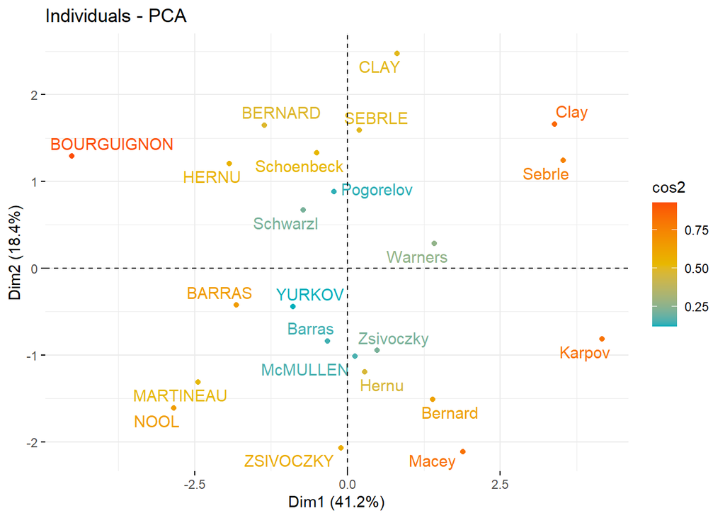

```r
fviz_pca_ind(active.pca, col.ind = "cos2",
             gradient.cols = c("#00AFBB", "#E7B800", "#FC4E07"),
             repel = TRUE
             )
```

# Question 15

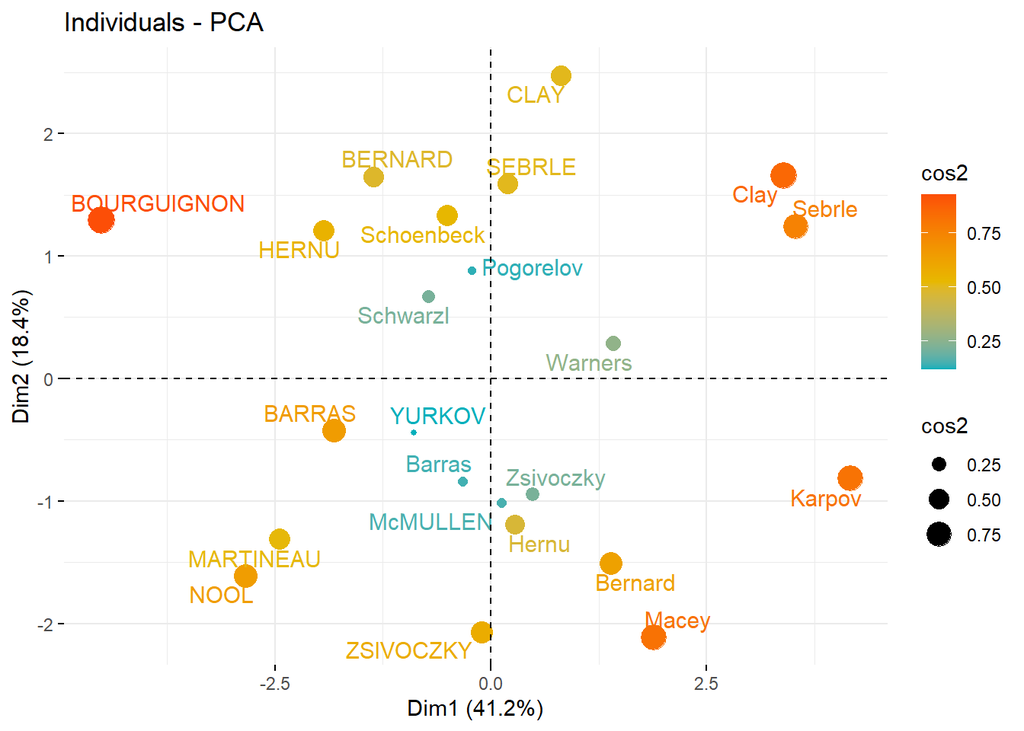

```r
fviz_pca_ind(active.pca, col.ind = "cos2", pointsize = "cos2",
             gradient.cols = c("#00AFBB", "#E7B800", "#FC4E07"),
             repel = TRUE
             )
```

# Question 16

```r
res.pca <- PCA(decathlon2, ind.sup= 24:27, quanti.sup = 11:12, quali.sup=13)
```

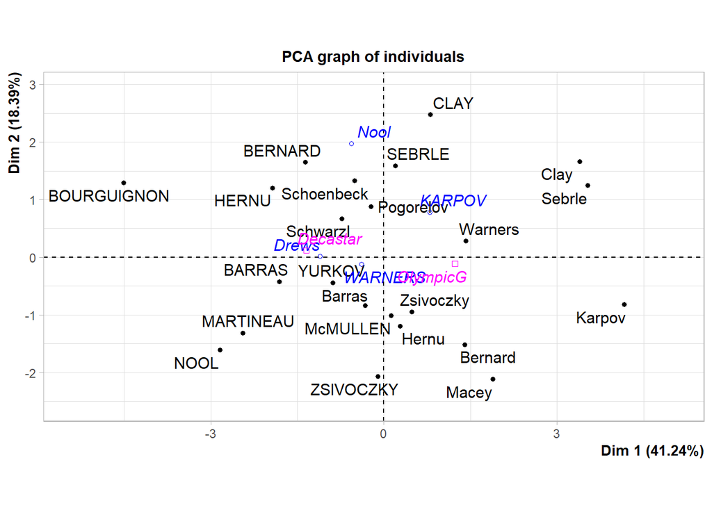

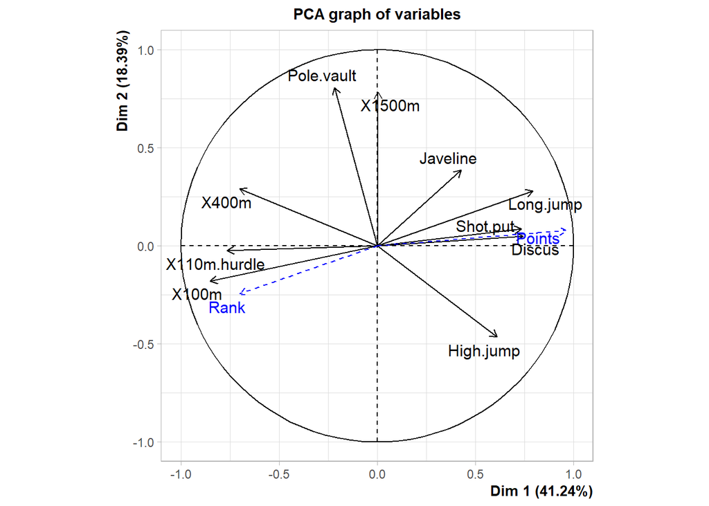

# Question 17

> Predicted results (coordinates, correlation and cos2) for the supplementary quantitative variables:

```r
res.pca$quanti.sup
```

```
## $coord
##             Dim.1       Dim.2      Dim.3       Dim.4       Dim.5
## Rank   -0.7014777 -0.24519443 -0.1834294  0.05575186 -0.07382647
## Points  0.9637075  0.07768262  0.1580225 -0.16623092 -0.03114711
##
## $cor
##             Dim.1       Dim.2      Dim.3       Dim.4       Dim.5
## Rank   -0.7014777 -0.24519443 -0.1834294  0.05575186 -0.07382647
## Points  0.9637075  0.07768262  0.1580225 -0.16623092 -0.03114711
##
## $cos2
##            Dim.1       Dim.2      Dim.3      Dim.4        Dim.5
## Rank   0.4920710 0.060120310 0.03364635 0.00310827 0.0054503477
## Points 0.9287322 0.006034589 0.02497110 0.02763272 0.0009701427
```

# Question 18

> Predict results for the supplementary individuals (ind.sup)

```r
res.pca$ind.sup
```

```
## $coord
##              Dim.1       Dim.2      Dim.3      Dim.4       Dim.5
## KARPOV   0.7947206  0.77951227 -1.6330203  1.7242283 -0.75070396
## WARNERS -0.3864645 -0.12159237 -1.7387332 -0.7063341 -0.03230011
## Nool    -0.5591306  1.97748871 -0.4830358 -2.2784526 -0.25461493
## Drews   -1.1092038  0.01741477 -3.0488182 -1.5343468 -0.32642192
##
## $cos2
##              Dim.1        Dim.2      Dim.3      Dim.4        Dim.5
## KARPOV  0.05104677 4.911173e-02 0.21553730 0.24028620 0.0455487744
## WARNERS 0.02422707 2.398250e-03 0.49039677 0.08092862 0.0001692349
## Nool    0.02897149 3.623868e-01 0.02162236 0.48108780 0.0060077529
## Drews   0.09207094 2.269527e-05 0.69560547 0.17617609 0.0079736753
##
## $dist
##   KARPOV  WARNERS     Nool    Drews
## 3.517470 2.482899 3.284943 3.655527
```

> Let’s visualize them together:

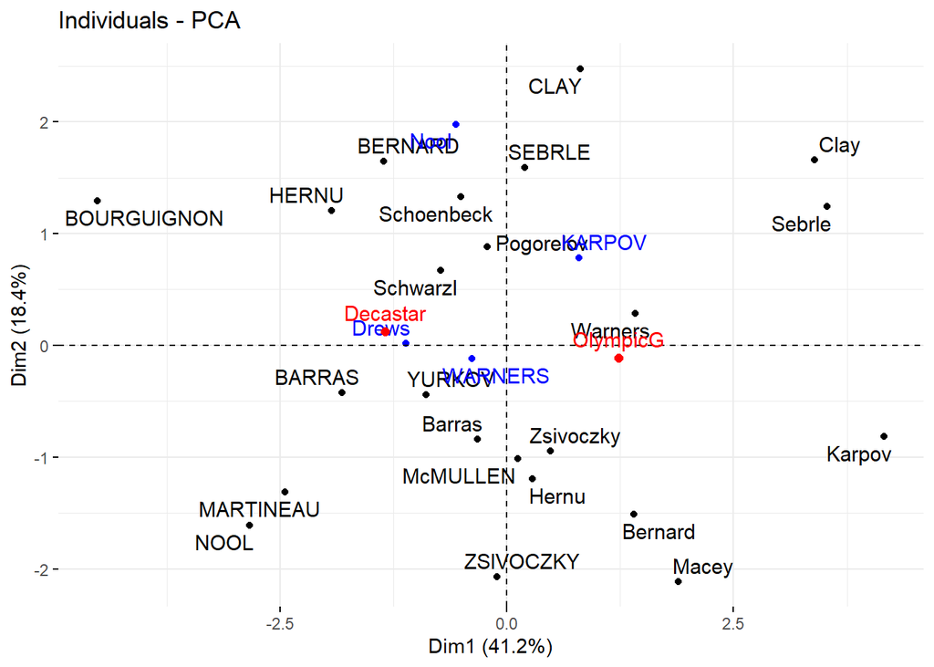

```r
plot <- fviz_pca_ind(res.pca, col.ind.sup = "blue", repel = TRUE)
plot <- fviz_add(plot, res.pca$quali.sup$coord, color = "red")
plot
```

# Question 19

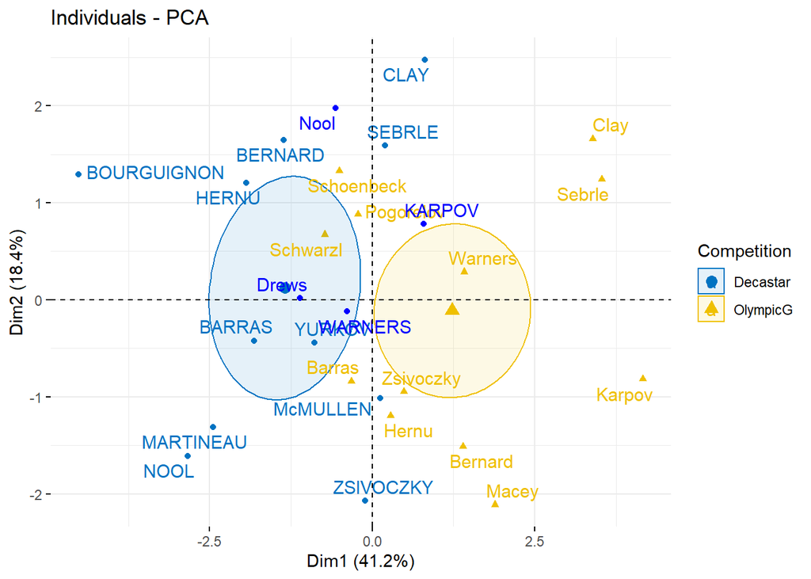

```r
fviz_pca_ind(res.pca, habillage = 13,
             addEllipses =TRUE, ellipse.type = "confidence",
             palette = "jco",
             repel = TRUE)
```

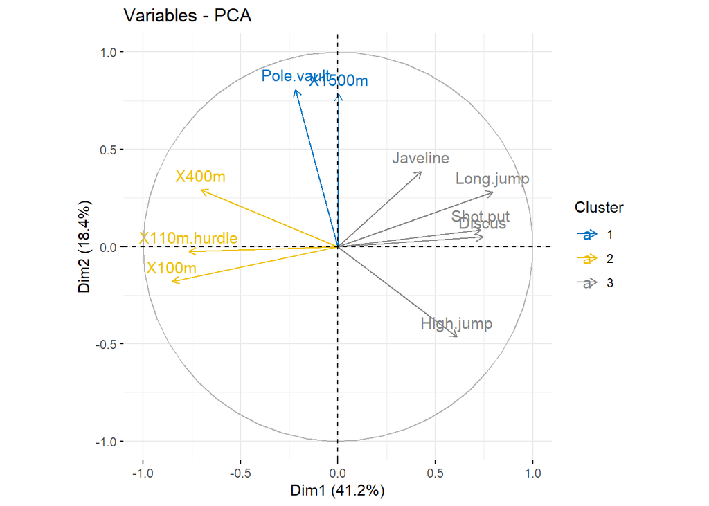

```r
set.seed(123)
res.km <- kmeans(vvar$coord, centers = 3, nstart = 25)
grp <- as.factor(res.km$cluster)

fviz_pca_var(active.pca, col.var = grp,
             palette = c("#0073C2FF", "#EFC000FF", "#868686FF"),
             legend.title = "Cluster")
```

# Question 20

> Let’s start with the correlation graph of the variables: We know that: - Positively correlated variables are clustered. - Negatively correlated variables are positioned on opposite sides of the origin of the graph (opposite quadrants). - The distance between the variables and the origin measures the quality of the representation of the variables. Variables that are far from the origin are well represented by the PCA. Thus we can conclude that the variables, the sprint type events (X100m, X110m.hurdle and X400m) are positively correlated with each other; but negatively correlated with the variables, the strength and jump type events (Javelin, Long; jump, Shot.put, Discus, High.jump). The variables, the best represented events are: X100m, Long.jump and Pole.vault.

# *Example 2 : IRIS Data*

# Question 1

```r
data("iris")
head(iris)
```

```
##   Sepal.Length Sepal.Width Petal.Length Petal.Width Species
## 1          5.1         3.5          1.4         0.2  setosa
## 2          4.9         3.0          1.4         0.2  setosa
## 3          4.7         3.2          1.3         0.2  setosa
## 4          4.6         3.1          1.5         0.2  setosa
## 5          5.0         3.6          1.4         0.2  setosa
## 6          5.4         3.9          1.7         0.4  setosa
```

```r
corm <- cor(iris[,1:4])
corm
```

```
##              Sepal.Length Sepal.Width Petal.Length Petal.Width
## Sepal.Length    1.0000000  -0.1175698    0.8717538   0.8179411
## Sepal.Width    -0.1175698   1.0000000   -0.4284401  -0.3661259
## Petal.Length    0.8717538  -0.4284401    1.0000000   0.9628654
## Petal.Width     0.8179411  -0.3661259    0.9628654   1.0000000
```

# Question 2

```r
data <- aggregate(.~Species, iris, mean)
```

#Question 3

```r
library(ggplot2)
library(reshape2)

iris2 <- melt(iris, id.vars="Species")
iris2[1:3,]
```

```
##   Species     variable value
## 1  setosa Sepal.Length   5.1
## 2  setosa Sepal.Length   4.9
## 3  setosa Sepal.Length   4.7
```

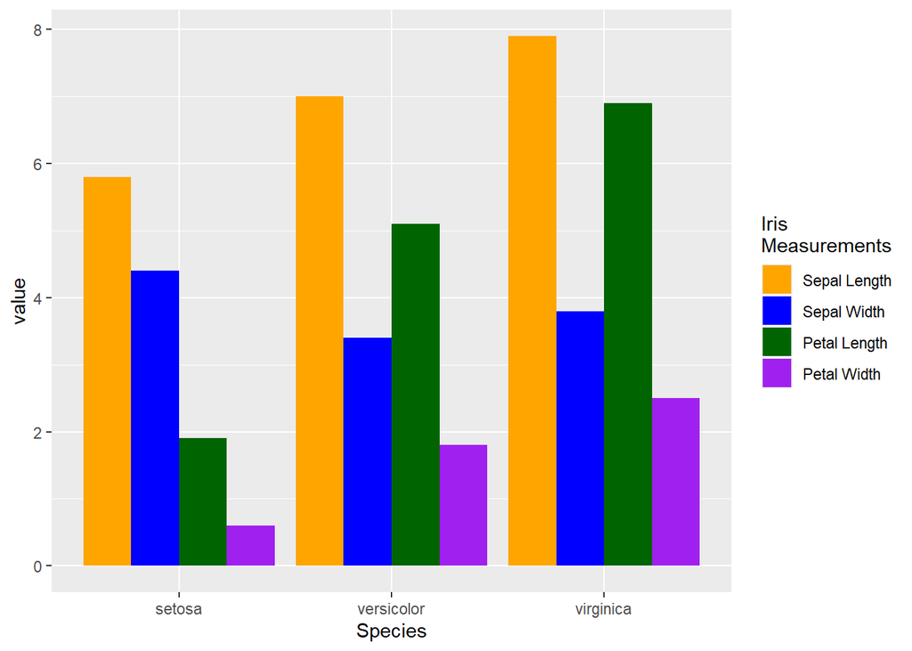

```r
bar1 <- ggplot(data=iris2, aes(x=Species, y=value, fill=variable))
bar1 + geom_bar(stat="identity", position="dodge") +
  scale_fill_manual(values=c("orange", "blue", "darkgreen", "purple"),
                    name="Iris\nMeasurements",
                    breaks=c("Sepal.Length", "Sepal.Width", "Petal.Length", "Petal.Width"),
                    labels=c("Sepal Length", "Sepal Width", "Petal Length", "Petal Width"))
```

# Question 4

```r
iris.pca <- princomp(iris[,1:4])
iris.pca
```

```
## Call:
## princomp(x = iris[, 1:4])
##
## Standard deviations:
##    Comp.1    Comp.2    Comp.3    Comp.4
## 2.0494032 0.4909714 0.2787259 0.1538707
##
##  4  variables and  150 observations.
```

```r
summary(iris.pca)
```

```
## Importance of components:
##                           Comp.1     Comp.2     Comp.3      Comp.4
## Standard deviation     2.0494032 0.49097143 0.27872586 0.153870700
## Proportion of Variance 0.9246187 0.05306648 0.01710261 0.005212184
## Cumulative Proportion  0.9246187 0.97768521 0.99478782 1.000000000
```

> With these tables, we can see that dimension 1 explains 92.46% of the data. Thus, the 1st dimension is very important. Let’s continue the study:

# Question 5

> Eigenvalues

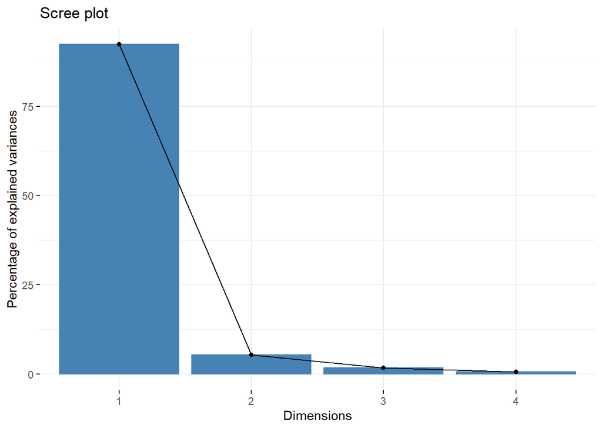

```r
fviz_eig(iris.pca)
```

>The graph of individuals

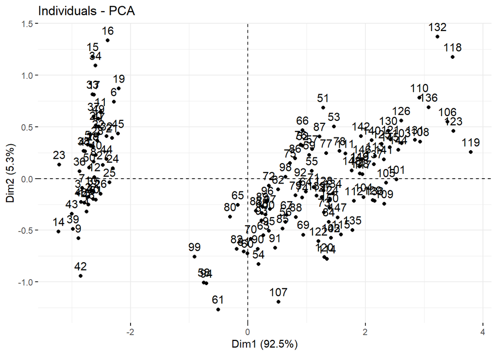

```r
fviz_pca_ind(iris.pca)
```

> The graph of variables

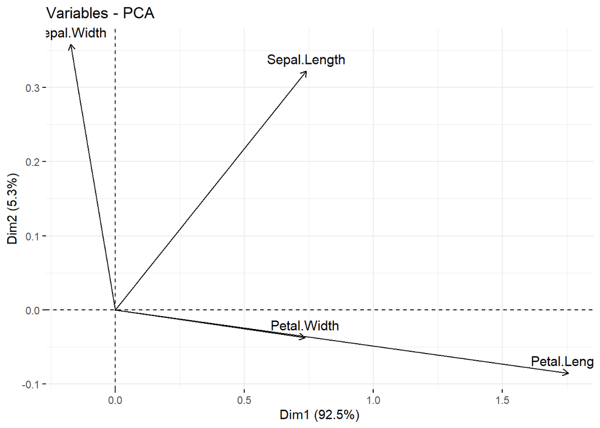

```r
fviz_pca_var(iris.pca)
```

> The biplot graph

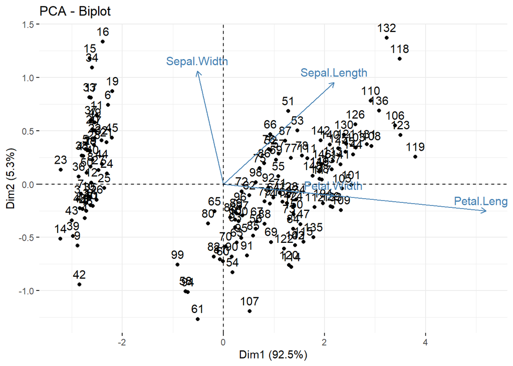

```r
fviz_pca_biplot(iris.pca)
```

> The contributions of the variables to the first 2 principal components

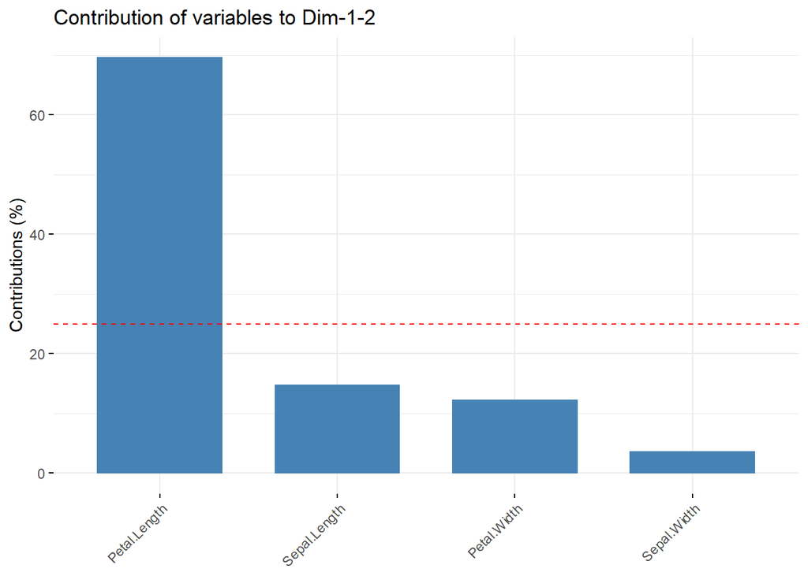

```r
fviz_contrib(iris.pca, choice = "var", axes = 1:2, top = 10)
```

# *Example 3 (Extra) : Step-by-step PCA*

# Question 1

```r
test <- iris
nams <- as.vector(iris$Species)
row.names(test) <- make.names(nams, unique= TRUE)
```

```r
X <- iris[, 1:4]
Y <- iris$Species
```

# Question 2

```r
scaledX <- scale(X)
```

# Question 3

```r
corm <- cor(scaledX)
corm
```

```
##              Sepal.Length Sepal.Width Petal.Length Petal.Width
## Sepal.Length    1.0000000  -0.1175698    0.8717538   0.8179411
## Sepal.Width    -0.1175698   1.0000000   -0.4284401  -0.3661259
## Petal.Length    0.8717538  -0.4284401    1.0000000   0.9628654
## Petal.Width     0.8179411  -0.3661259    0.9628654   1.0000000
```

# Question 4 & 5

```r
eigd <- eigen(corm)
eigd
```

```
## eigen() decomposition
## $values
## [1] 2.91849782 0.91403047 0.14675688 0.02071484
##
## $vectors
##            [,1]        [,2]       [,3]       [,4]
## [1,]  0.5210659 -0.37741762  0.7195664  0.2612863
## [2,] -0.2693474 -0.92329566 -0.2443818 -0.1235096
## [3,]  0.5804131 -0.02449161 -0.1421264 -0.8014492
## [4,]  0.5648565 -0.06694199 -0.6342727  0.5235971
```

# Question 6

```r
rawcorm <- cor(X)
rawcorm
```

```
##              Sepal.Length Sepal.Width Petal.Length Petal.Width
## Sepal.Length    1.0000000  -0.1175698    0.8717538   0.8179411
## Sepal.Width    -0.1175698   1.0000000   -0.4284401  -0.3661259
## Petal.Length    0.8717538  -0.4284401    1.0000000   0.9628654
## Petal.Width     0.8179411  -0.3661259    0.9628654   1.0000000
```

# Question 7

```r
iris.pca <- PCA(scaledX)
```

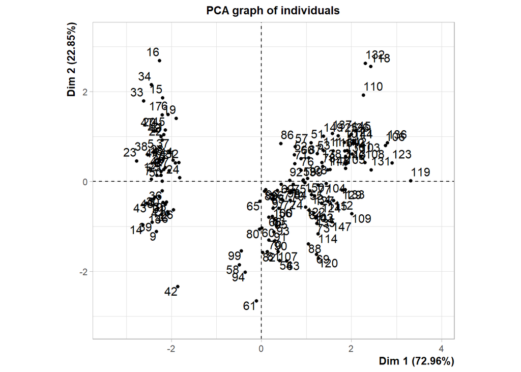

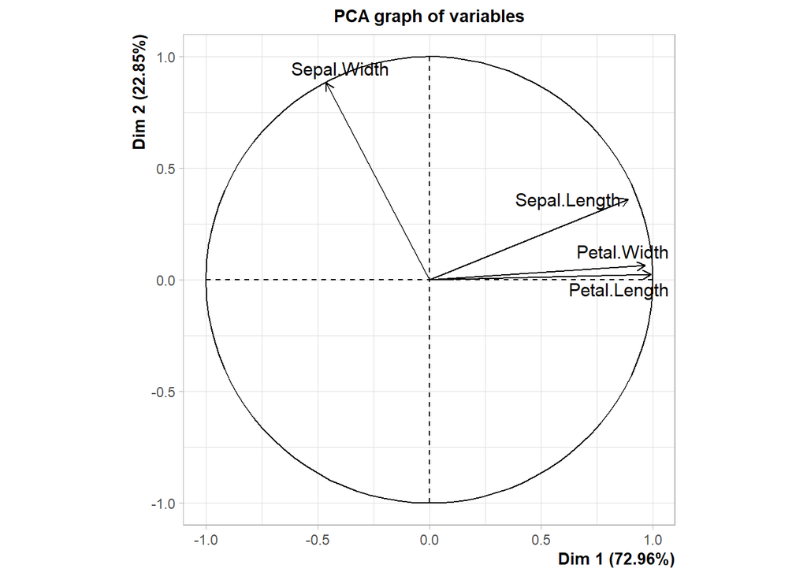

```r
iris.pca$eig
```

```
##        eigenvalue percentage of variance cumulative percentage of variance
## comp 1 2.91849782             72.9624454                          72.96245
## comp 2 0.91403047             22.8507618                          95.81321
## comp 3 0.14675688              3.6689219                          99.48213
## comp 4 0.02071484              0.5178709                         100.00000
```

```r
eigd
```

```
## eigen() decomposition
## $values
## [1] 2.91849782 0.91403047 0.14675688 0.02071484
##
## $vectors
##            [,1]        [,2]       [,3]       [,4]
## [1,]  0.5210659 -0.37741762  0.7195664  0.2612863
## [2,] -0.2693474 -0.92329566 -0.2443818 -0.1235096
## [3,]  0.5804131 -0.02449161 -0.1421264 -0.8014492
## [4,]  0.5648565 -0.06694199 -0.6342727  0.5235971
```